# Recap of class 2

- Recap of class 2 topics
- Class 2 homework review

# NA Values

NA is a blank value used to represent an unknown value. This is superior to using “” or 0 because those can be mis-interpreted as values.

# Why Explore, Visualize, and Clean Data

Data exploration is incredibly useful to understand what variables (columns) are available, and what types of values exist. Exploration and visualization can help discover when bad data exists by looking for ourliers or trends that don’t make sense. Since any analysis requires good and clean data, this is an absolute must for every data analysis a scientist conducts.

It is easily overlooked and commonly cited as the worst or most time-consuming part of an analyst’s job. R can greatly help increase accuracy and reduce work on this step. Skipping it altogether would be a huge mistake with regards to the validity of conclusions.

Common functions: - str (or use RStudio GUI) - summary - head / View - unique / table

Quick visualization: - qplot - ggplot

# ggplot2

The grammar of graphics. Uses a small number of common “verbs” and very standardized syntax to enable the programmer to describe any chart they can imagine.

Note: I will not cover all details of ggplot2 because they are so specific to the graph you are trying to build. There is ample online documentation [here](http://ggplot2.tidyverse.org/reference/).

Common geometric shapes: - geom_histogram - geom_density - geom_point - geom_bar - geom_line

# Practical exercises

Load required packages

```r
library(tidyverse)
library(yarrr)
# Copy dataset to Global Environment
df <- pirateserrors
```

Start exploring variables and looking for outliers or errors

```r
# Review column values
?pirateserrors
str(df)
```

```
## 'data.frame':    1000 obs. of  14 variables:
##  $ id             : int  1 2 3 4 5 6 7 8 9 10 ...
##  $ sex            : chr  "female" "male" "male" "male" ...
##  $ headband       : chr  "yes" "yes" "yes" "yes" ...
##  $ age            : num  30 25 25 29 31 30 33 35 25 34 ...
##  $ college        : chr  "JSSFP" "CCCC" "CCCC" "JSSFP" ...
##  $ tattoos        : num  11 15 12 12 17 12 9 13 9 9 ...
##  $ tchests        : num  20 6 5 0 11 2 3 7 9 13 ...
##  $ parrots        : num  7 3 2 1 10 2 3 11 4 1 ...
##  $ favorite.pirate: chr  "Blackbeard" "Anicetus" "Jack Sparrow" "Edward Low" ...
##  $ sword.type     : chr  "cutlass" "cutlass" "cutlass" "cutlass" ...
##  $ sword.time     : num  0.83 0.03 1.44 0.18 0.64 ...
##  $ eyepatch       : num  1 1 0 1 1 1 1 1 1 1 ...
##  $ beard.length   : num  0 16 21 21 0 22 0 2 20 0 ...
##  $ fav.pixar      : chr  "Up" "Toy Story 2" "Cars" "The Incredibles" ...
```

```r
summary(df)
```

```
##        id             sex              headband              age
##  Min.   :   1.0   Length:1000        Length:1000        Min.   :  -99.00
##  1st Qu.: 251.0   Class :character   Class :character   1st Qu.:   23.00
##  Median : 501.0   Mode  :character   Mode  :character   Median :   27.00
##  Mean   : 500.8                                         Mean   :   56.62
##  3rd Qu.: 751.0                                         3rd Qu.:   31.00
##  Max.   :1000.0                                         Max.   :12345.00
##  NA's   :3                                              NA's   :3
##    college             tattoos           tchests          parrots
##  Length:1000        Min.   :    -10   Min.   :   0.0   Min.   :  0.0
##  Class :character   1st Qu.:      7   1st Qu.:   2.0   1st Qu.:  1.0
##  Mode  :character   Median :     10   Median :   5.0   Median :  2.0
##                     Mean   :   4042   Mean   : 117.9   Mean   : 17.7
##                     3rd Qu.:     12   3rd Qu.:  10.0   3rd Qu.:  4.0
##                     Max.   :1000000   Max.   :9710.0   Max.   :997.0
##                     NA's   :8         NA's   :1        NA's   :6
##  favorite.pirate     sword.type          sword.time         eyepatch
##  Length:1000        Length:1000        Min.   :  0.000   Min.   : 0.0000
##  Class :character   Class :character   1st Qu.:  0.280   1st Qu.: 0.0000
##  Mode  :character   Mode  :character   Median :  0.650   Median : 1.0000
##                                        Mean   :  2.252   Mean   : 0.7676
##                                        3rd Qu.:  1.330   3rd Qu.: 1.0000
##                                        Max.   :198.200   Max.   :10.0000
##                                        NA's   :2         NA's   :6
##   beard.length     fav.pixar
##  Min.   : 0.000   Length:1000
##  1st Qu.: 0.000   Class :character
##  Median : 6.000   Mode  :character
##  Mean   : 9.809
##  3rd Qu.:19.000
##  Max.   :38.000
##  NA's   :3
```

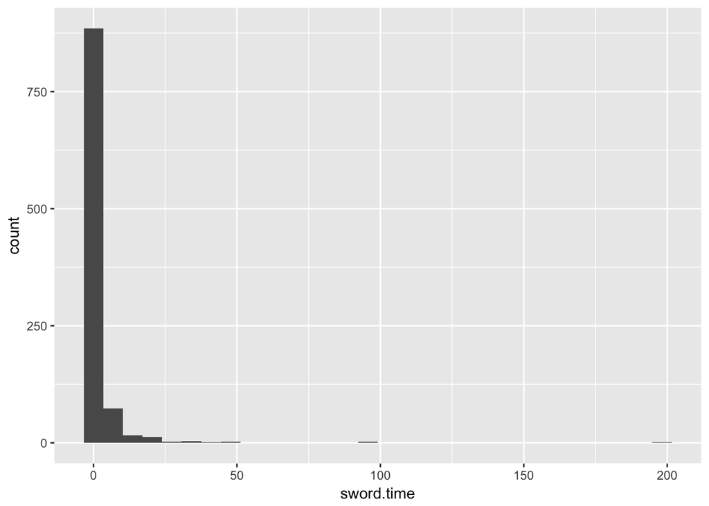

```r
# Visualize
ggplot(data = df, aes(x = sword.time)) + geom_histogram()
```

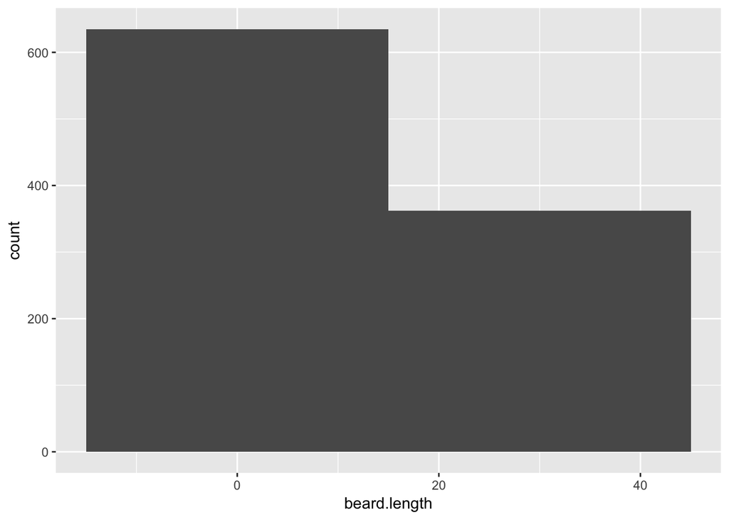

```r
ggplot(data = df, aes(x = beard.length)) + geom_histogram(binwidth = 30)
```

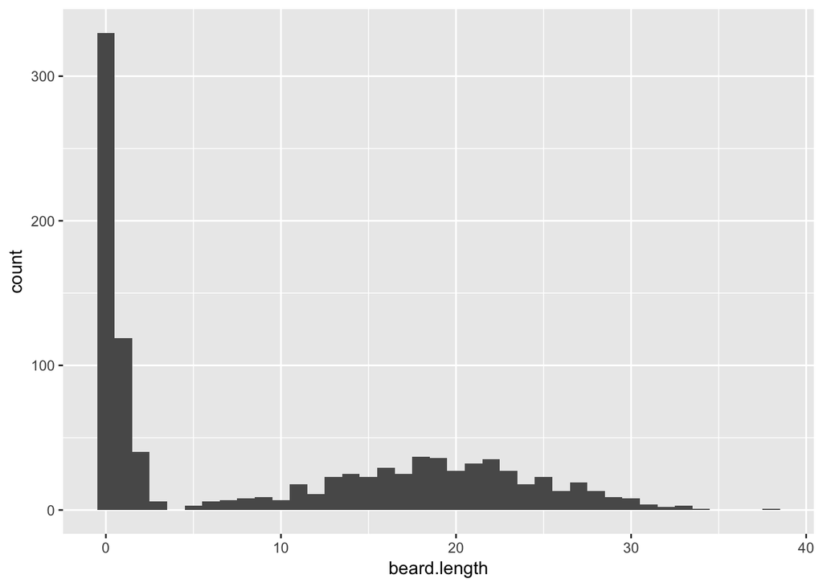

```r
ggplot(data = df, aes(x = beard.length)) + geom_histogram(binwidth = 1)
```

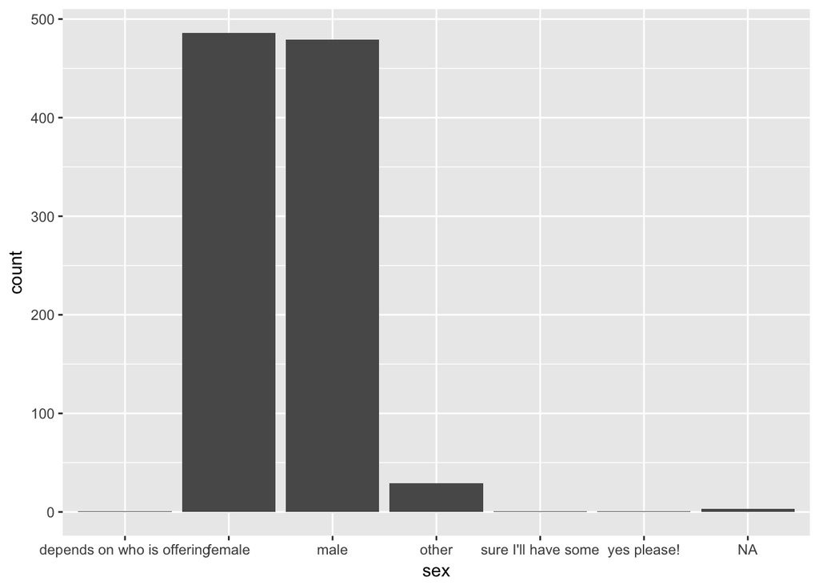

```r
ggplot(data = df, aes(x = sex)) + geom_histogram(stat = "count")
```

```r
# Find all values you do not want
df %>%
  filter(sex != "female") %>%
  filter(sex != "male") %>%
  filter(sex != "other") %>%
  select(sex) %>%
  unique()
```

```
##                          sex
## 1 depends on who is offering
## 2                yes please!
## 3        sure I'll have some
```

Must understand creation of logical vectors to clean data more effectively; often times we know what “real” data looks like and want to replace all “bad” values

```r
# Demo creating opposite locical vector
df$sex %in% c("male", "female", "other")
```

```
##    [1]  TRUE  TRUE  TRUE  TRUE  TRUE  TRUE  TRUE  TRUE  TRUE  TRUE  TRUE
##   [12]  TRUE  TRUE  TRUE  TRUE  TRUE  TRUE  TRUE  TRUE  TRUE  TRUE  TRUE
##   [23]  TRUE  TRUE  TRUE  TRUE  TRUE  TRUE  TRUE  TRUE  TRUE  TRUE  TRUE
##   [34]  TRUE  TRUE  TRUE  TRUE  TRUE  TRUE  TRUE  TRUE  TRUE  TRUE  TRUE
##   [45]  TRUE  TRUE  TRUE  TRUE  TRUE  TRUE  TRUE  TRUE  TRUE  TRUE  TRUE
##   [56]  TRUE  TRUE  TRUE  TRUE  TRUE  TRUE  TRUE  TRUE  TRUE  TRUE  TRUE
##   [67]  TRUE  TRUE  TRUE  TRUE  TRUE  TRUE  TRUE  TRUE  TRUE  TRUE  TRUE
##   [78]  TRUE  TRUE  TRUE  TRUE  TRUE  TRUE  TRUE  TRUE FALSE  TRUE  TRUE
##   [89]  TRUE  TRUE  TRUE  TRUE  TRUE  TRUE  TRUE  TRUE  TRUE  TRUE  TRUE
##  [100]  TRUE  TRUE  TRUE  TRUE  TRUE  TRUE  TRUE  TRUE  TRUE  TRUE  TRUE
##  [111]  TRUE  TRUE  TRUE  TRUE  TRUE  TRUE  TRUE  TRUE  TRUE  TRUE  TRUE
##  [122]  TRUE  TRUE  TRUE  TRUE  TRUE  TRUE  TRUE  TRUE  TRUE  TRUE  TRUE
##  [133]  TRUE  TRUE  TRUE  TRUE  TRUE  TRUE  TRUE  TRUE  TRUE  TRUE  TRUE
##  [144]  TRUE  TRUE  TRUE  TRUE  TRUE  TRUE  TRUE  TRUE  TRUE  TRUE  TRUE
##  [155]  TRUE  TRUE  TRUE  TRUE  TRUE  TRUE  TRUE  TRUE  TRUE  TRUE  TRUE
```

[output cut: 76 more lines]

```r
!(df$sex %in% c("male", "female", "other"))
```

```
##    [1] FALSE FALSE FALSE FALSE FALSE FALSE FALSE FALSE FALSE FALSE FALSE
##   [12] FALSE FALSE FALSE FALSE FALSE FALSE FALSE FALSE FALSE FALSE FALSE
##   [23] FALSE FALSE FALSE FALSE FALSE FALSE FALSE FALSE FALSE FALSE FALSE
##   [34] FALSE FALSE FALSE FALSE FALSE FALSE FALSE FALSE FALSE FALSE FALSE
##   [45] FALSE FALSE FALSE FALSE FALSE FALSE FALSE FALSE FALSE FALSE FALSE
##   [56] FALSE FALSE FALSE FALSE FALSE FALSE FALSE FALSE FALSE FALSE FALSE
##   [67] FALSE FALSE FALSE FALSE FALSE FALSE FALSE FALSE FALSE FALSE FALSE
##   [78] FALSE FALSE FALSE FALSE FALSE FALSE FALSE FALSE  TRUE FALSE FALSE
##   [89] FALSE FALSE FALSE FALSE FALSE FALSE FALSE FALSE FALSE FALSE FALSE
##  [100] FALSE FALSE FALSE FALSE FALSE FALSE FALSE FALSE FALSE FALSE FALSE
##  [111] FALSE FALSE FALSE FALSE FALSE FALSE FALSE FALSE FALSE FALSE FALSE
##  [122] FALSE FALSE FALSE FALSE FALSE FALSE FALSE FALSE FALSE FALSE FALSE
##  [133] FALSE FALSE FALSE FALSE FALSE FALSE FALSE FALSE FALSE FALSE FALSE
##  [144] FALSE FALSE FALSE FALSE FALSE FALSE FALSE FALSE FALSE FALSE FALSE
##  [155] FALSE FALSE FALSE FALSE FALSE FALSE FALSE FALSE FALSE FALSE FALSE
```

[output cut: 76 more lines]

```r
# Start making mutations to data.frame
df2 <- df

# Replace values with NA
df2 <- df2 %>%
  mutate(sex = ifelse(sex %in% c("male", "female", "other"), sex, NA))

df2 <- df2 %>%
  mutate(sex = ifelse(!(sex %in% c("male", "female", "other")), NA, sex))
```

Complete cases can be used when NA values in columns invalidate entire measurement

```r
# Doing an analysis on gender, so only want valid records
df2 <- df2 %>%
  filter(complete.cases(df2))
```

The caret::nzv function can be used to check for near-zero-variance variables

```r
library(caret)
nzv(df2)
```

```
## integer(0)
```

ggpairs in the GGally library can be used to create a plot matrix and visualize many vairables and their relationships

```r
# install.packages("GGally")
library(GGally)
```

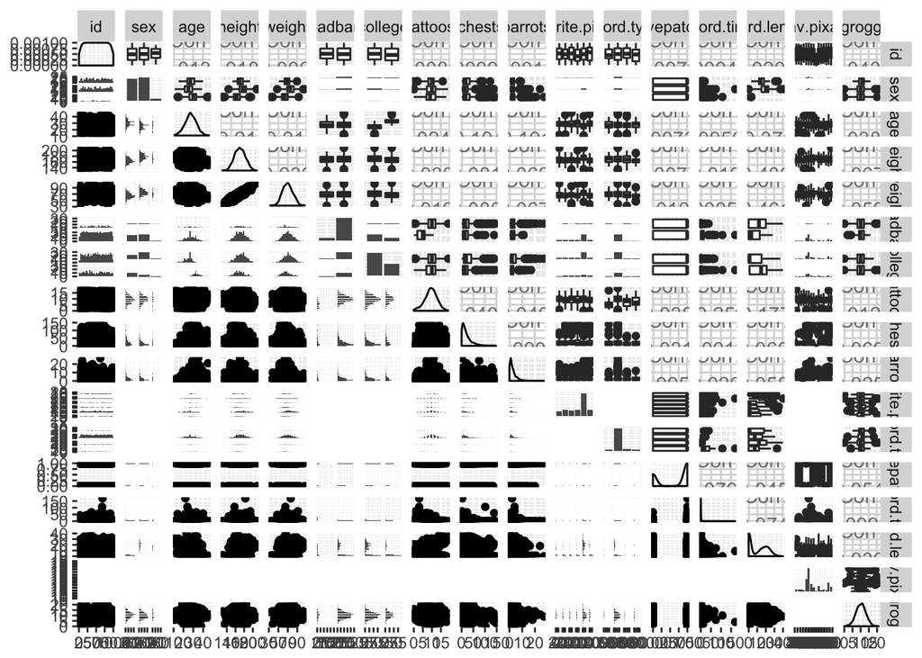

```r
ggpairs(yarrr::pirates)
```

# Homework

For this class, complete the following homework assignments:

- Review the [data visualization cheat sheet](https://www.rstudio.com/resources/cheatsheets/)
- Complete the Swirl R Programming Basic Building Blocks lessons
- Finish cleaning the yarrr::pirateserrors dataset; consider what analytical decisions must be made and why; recognize that any such choice has associated pros and cons which impact final conclusions of the analysis
- Practice cleaning and visualizing data from your selected data analysis and getting it tidy for analysis